# Travel Data Analysis

2023-05-20

# Business Understanding.

In this case, the given data deals with travel data of passengers, I would like to focus on the premium. My objective is to understand how does the premium amount differ in view of the different set of variables. What i mean is, what factors affects the premium amount and what does it mean for the business. To understand what circumstances would result to higher premium.

# Data understanding.

This part entails data cleaning and ensuring that the data is ready for exploration. This part also comes with some Exploratory Data Analysis I have done just to understand the data better, formulate questions or draw new insights. ## Travel data.

```
##    SV.NUMBER                 ORIGIN                           DESTINATION
## 1     112383      Nairobi, NAIROBI                   Kajiado, LERUAT LOG
## 2     112448      Nairobi, Nairobi                        Mombasa, Diani
## 3     112384       Nairobi, NAIROBI Laikipia, MAIYAN VILLA AND FAIRMOUNT
## 4     112447       Nairobi, Nairobi                      Mombasa, MOMBASA
## 5     112274       Nairobi, Nairobi         Mombasa, Voyager Beach Resort
## 6     112516      Nairobi, nairobi       Mombasa, travellers beach resort
## 7     112449                Nairobi                               Baobab
## 8     112386      Nairobi, nairobi            Mombasa, Hemingways Watamu
## 9     112385      Nairobi, nairobi    Mombasa, diani baobab beach resort
## 10    112387      Nairobi, nairobi    Mombasa, diani baobab beach resort
## 11    810681       Mombasa,  watamu                      Mombasa,  watamu
## 12    810682 Taita Taveta, saltlick                Taita Taveta, saltlick
## 13    810683       Nairobi, nairobi                      Mombasa, mombasa
## 14    810684       Nairobi, nairobi                     Narok, masai mara
```

[output cut: 33 more lines]

From the head of the dataset, I can already see data type mismatch. For example, the Departure column is supposed to be of type Date, however it a character. This means I have correct the data types before proceeding.

## Summary of the data.

```
##    SV.NUMBER         ORIGIN          DESTINATION        OTHER.DESTINATIONS
##  Min.   :103130   Length:5443        Length:5443        Min.   :0.000000
##  1st Qu.:322766   Class :character   Class :character   1st Qu.:0.000000
##  Median :429757   Mode  :character   Mode  :character   Median :0.000000
##  Mean   :446626                                         Mean   :0.004042
##  3rd Qu.:610178                                         3rd Qu.:0.000000
##  Max.   :905517                                         Max.   :2.000000
##   DEPARTURE         RETURN.DATE           PREMIUM          PASSENGERS
##  Length:5443        Length:5443        Min.   :  100.0   Min.   :  1.00
##  Class :character   Class :character   1st Qu.:  200.0   1st Qu.:  2.00
##  Mode  :character   Mode  :character   Median :  300.0   Median :  3.00
##                                        Mean   :  385.7   Mean   :  3.76
##                                        3rd Qu.:  400.0   3rd Qu.:  4.00
##                                        Max.   :12000.0   Max.   :120.00
##   CREATED.BY           BRANCH          DATE.POSTED          MODIFIED
##  Length:5443        Length:5443        Length:5443        Length:5443
##  Class :character   Class :character   Class :character   Class :character
##  Mode  :character   Mode  :character   Mode  :character   Mode  :character
##
##
##
```

I used summary(), its a function that gives me the summary of the entire dataframe. From the summary I can see all columns and their respective data types. From this I can deduce which columns to handle in terms of data type. Below is where I do the conversion. ## Data type conversion.

```
##   SV.NUMBER            ORIGIN                           DESTINATION
## 1    112383 Nairobi, NAIROBI                   Kajiado, LERUAT LOG
## 2    112448 Nairobi, Nairobi                        Mombasa, Diani
## 3    112384  Nairobi, NAIROBI Laikipia, MAIYAN VILLA AND FAIRMOUNT
## 4    112447  Nairobi, Nairobi                      Mombasa, MOMBASA
## 5    112274  Nairobi, Nairobi         Mombasa, Voyager Beach Resort
##   OTHER.DESTINATIONS  DEPARTURE RETURN.DATE PREMIUM PASSENGERS CREATED.BY
## 1                  0 2022-09-03  2022-09-04     400          4     Joseph
## 2                  0 2022-09-05  2022-09-08     200          2    Vanessa
## 3                  0 2022-09-05  2022-09-07     200          2     Joseph
## 4                  0 2022-09-21  2022-09-27     400          2    Vanessa
## 5                  0 2022-09-03  2022-09-06     500          5     Alicia
##   BRANCH DATE.POSTED MODIFIED
## 1 Nakuru  0005-09-20       NO
## 2 Nakuru  0005-09-20       NO
## 3 Nakuru  0005-09-20       NO
## 4 Nakuru  0005-09-20       NO
## 5 Nakuru  0005-09-20       NO
```

Now that conversions have been made, its time to check for missing values. ## Checking for null values.

```
## [1] FALSE
```

I decided to split the Origin into two, the county itself and the location the passenger was visiting. This helps in the case where i may need to analyse travel habits of the passengers and use the information to provide data driven answers. ## Separating the origin and destination columns.

```
##   SV.NUMBER OriginCounty OriginLocation DestinationCounty
## 1    112383      Nairobi       NAIROBI            Kajiado
## 2    112448      Nairobi       Nairobi            Mombasa
## 3    112384      Nairobi        NAIROBI          Laikipia
## 4    112447      Nairobi        Nairobi           Mombasa
## 5    112274      Nairobi        Nairobi           Mombasa
##            DestinationLocation OTHER.DESTINATIONS  DEPARTURE RETURN.DATE
## 1                  LERUAT LOG                   0 2022-09-03  2022-09-04
## 2                       Diani                   0 2022-09-05  2022-09-08
## 3  MAIYAN VILLA AND FAIRMOUNT                   0 2022-09-05  2022-09-07
## 4                      MOMBASA                  0 2022-09-21  2022-09-27
## 5         Voyager Beach Resort                  0 2022-09-03  2022-09-06
##   PREMIUM PASSENGERS CREATED.BY BRANCH DATE.POSTED MODIFIED
## 1     400          4     Joseph Nakuru  0005-09-20       NO
## 2     200          2    Vanessa Nakuru  0005-09-20       NO
## 3     200          2     Joseph Nakuru  0005-09-20       NO
## 4     400          2    Vanessa Nakuru  0005-09-20       NO
## 5     500          5     Alicia Nakuru  0005-09-20       NO
```

## Checking branches involved.

Looking at the branch column, i want to know just how many branches are captured here in the data. I would also check on their respective engagement with clients/passengers. So they are arranged in a descending order, from the one with the highest frequncy to the lowest.

```
## # A tibble: 11 × 2
## # Groups:   BRANCH [11]
##    BRANCH            n
##    <chr>         <int>
##  1 "Lavington"    1293
##  2 "Yala"         1072
##  3 "Garden City"   675
##  4 "Ciata"         616
##  5 "Nextgen"       520
##  6 "Nakuru"        396
##  7 "Ridgeways"     379
##  8 "Nyali"         324
##  9 "Westgate"      134
## 10 "Westagate"      23
## 11 "Ciata "         11
```

From the above information, there are some branches that appear twice such as Ciata and other branches have been misspell that would be Westagate. It would be wise to correct that before proceeding.

## Combining same branches to one.

```
## # A tibble: 9 × 2
## # Groups:   BRANCH [9]
##   BRANCH          n
##   <chr>       <int>
## 1 Ciata         627
## 2 Garden City   675
## 3 Lavington    1293
## 4 Nakuru        396
## 5 Nextgen       520
## 6 Nyali         324
## 7 Ridgeways     379
## 8 Westgate      157
## 9 Yala         1072
```

# EDA.

## Premium Distribution.

Using a histogram would give a general view of the distribution of the premium. From the plot, its clear that there is a skew. Its a positive skew as the tail is on the right.

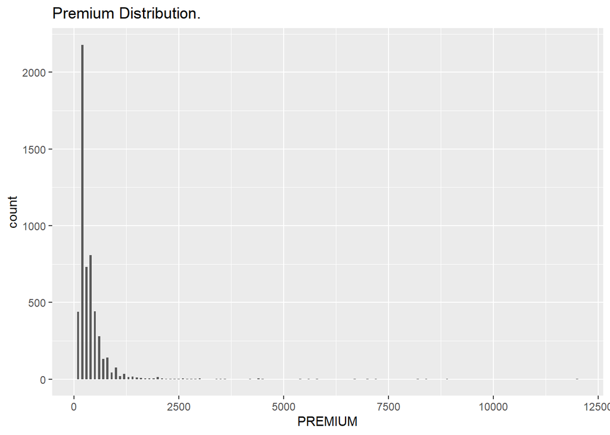

## Premium in relation to passengers. This gives the trend of how the premium varies with passengers. The hypothesis here is the more the passengers the more the premium, added a third factor, colored by branch. However, the results are abit different. There are a couple outliers that are suggesting something different. Could there be other factors involved that is cause the trend observed?

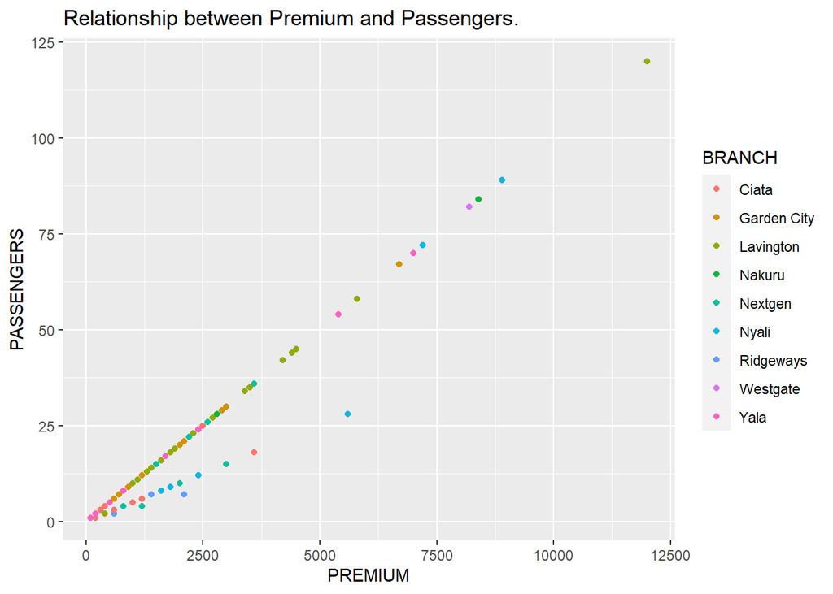

In an attempt to try and answer the above question, I decide to dig deeper into the individual branches and observe the the premium trend under the same set of variables. Interestingly, there were branches that depicted the exact same trend as observed above. There could be other factors that controls the trend observed.

## Investigating the trend.

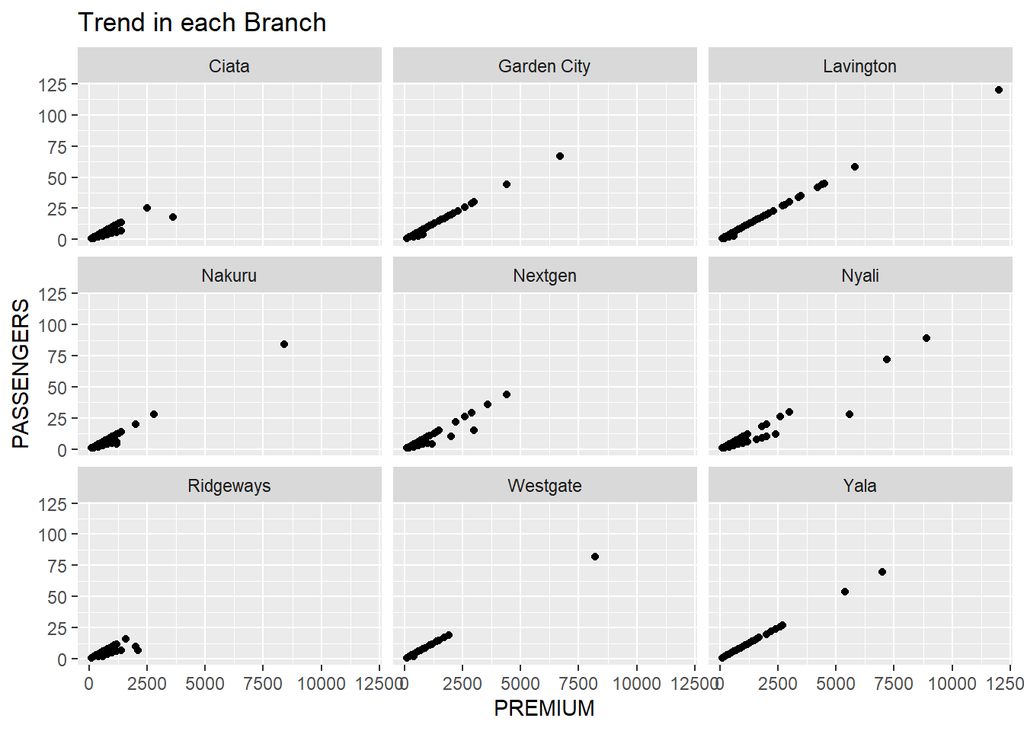

Could it be that the duration between Departure and Return date is the possible cause of the trend observed? In an attempt to investigate this, I created the new column that would hold the duration in days.

## Time difference.

```
##   SV.NUMBER OriginCounty OriginLocation DestinationCounty
## 1    112383      Nairobi       NAIROBI            Kajiado
## 2    112448      Nairobi       Nairobi            Mombasa
## 3    112384      Nairobi        NAIROBI          Laikipia
## 4    112447      Nairobi        Nairobi           Mombasa
## 5    112274      Nairobi        Nairobi           Mombasa
##            DestinationLocation OTHER.DESTINATIONS  DEPARTURE RETURN.DATE
## 1                  LERUAT LOG                   0 2022-09-03  2022-09-04
## 2                       Diani                   0 2022-09-05  2022-09-08
## 3  MAIYAN VILLA AND FAIRMOUNT                   0 2022-09-05  2022-09-07
## 4                      MOMBASA                  0 2022-09-21  2022-09-27
## 5         Voyager Beach Resort                  0 2022-09-03  2022-09-06
##   PREMIUM PASSENGERS CREATED.BY BRANCH DATE.POSTED MODIFIED Duration
## 1     400          4     Joseph Nakuru  0005-09-20       NO   1 days
## 2     200          2    Vanessa Nakuru  0005-09-20       NO   3 days
## 3     200          2     Joseph Nakuru  0005-09-20       NO   2 days
## 4     400          2    Vanessa Nakuru  0005-09-20       NO   6 days
## 5     500          5     Alicia Nakuru  0005-09-20       NO   3 days
```

Now that the column is created and populated, its possible to explore and see if it might bring answers or raise more questions, or even give new insights.

## Premium against Duration.

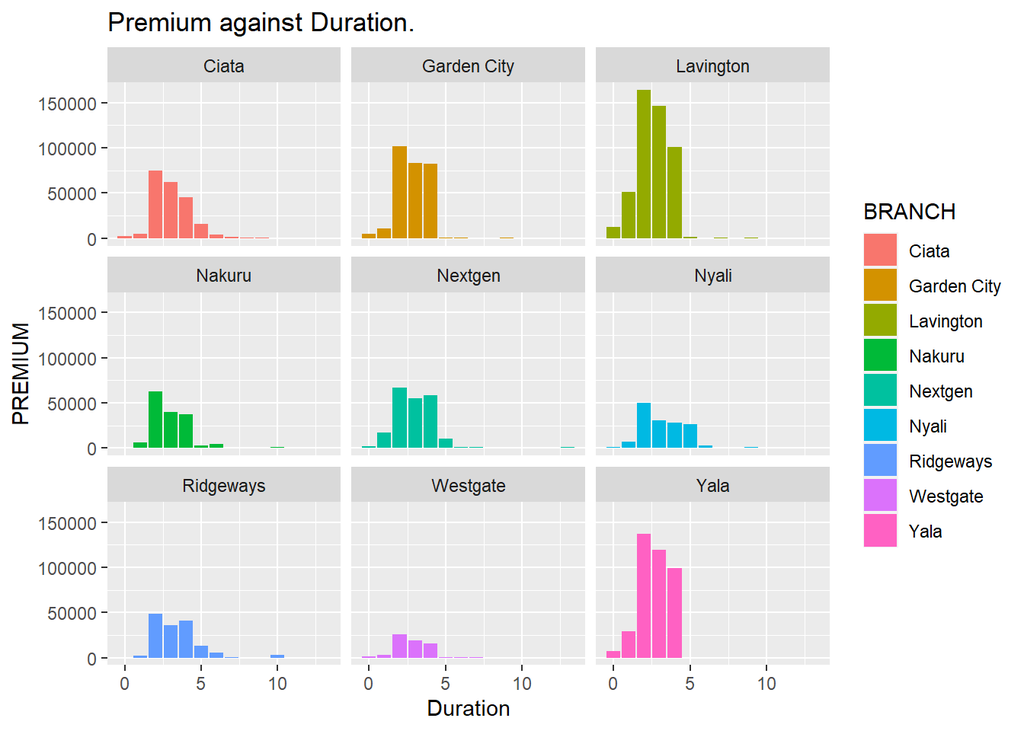

From the above graph, it is clear that premium is not entirely defined by the duration.The hypothesis to be tested here was, does longer duration mean more premium? Actually from the graph its clear that short duration have more premiums. Now, lets take a look at the performance of each branch.

## Branch with the most count.

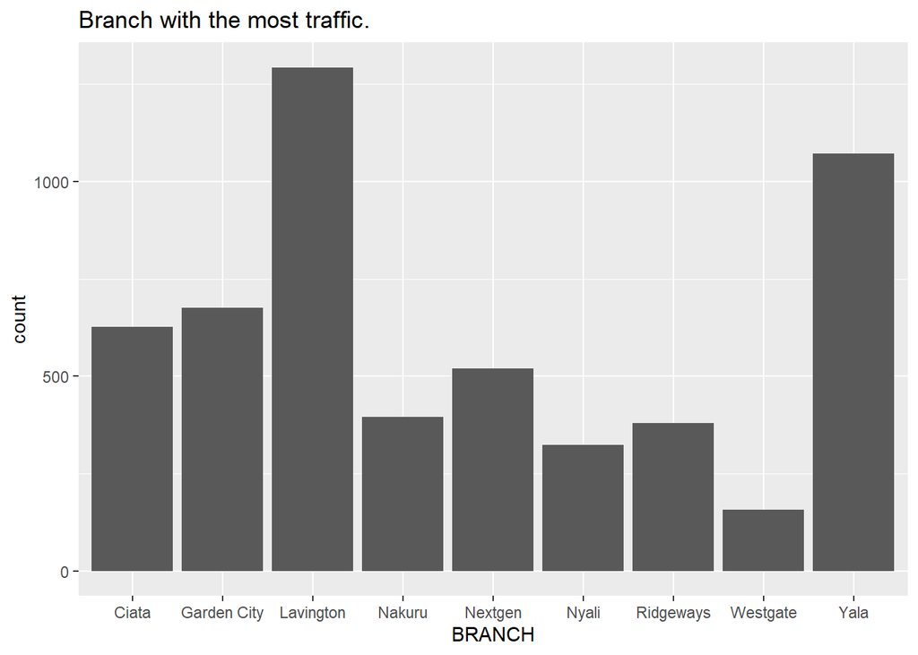

From the above graph, the branch with the highest frequency is Lavington. It had the most client engagement. Could one of the reasons be that their customer service is up to the client standards and supported by the location Next am touching on the premium in each branch.

## Branch relation to premium.

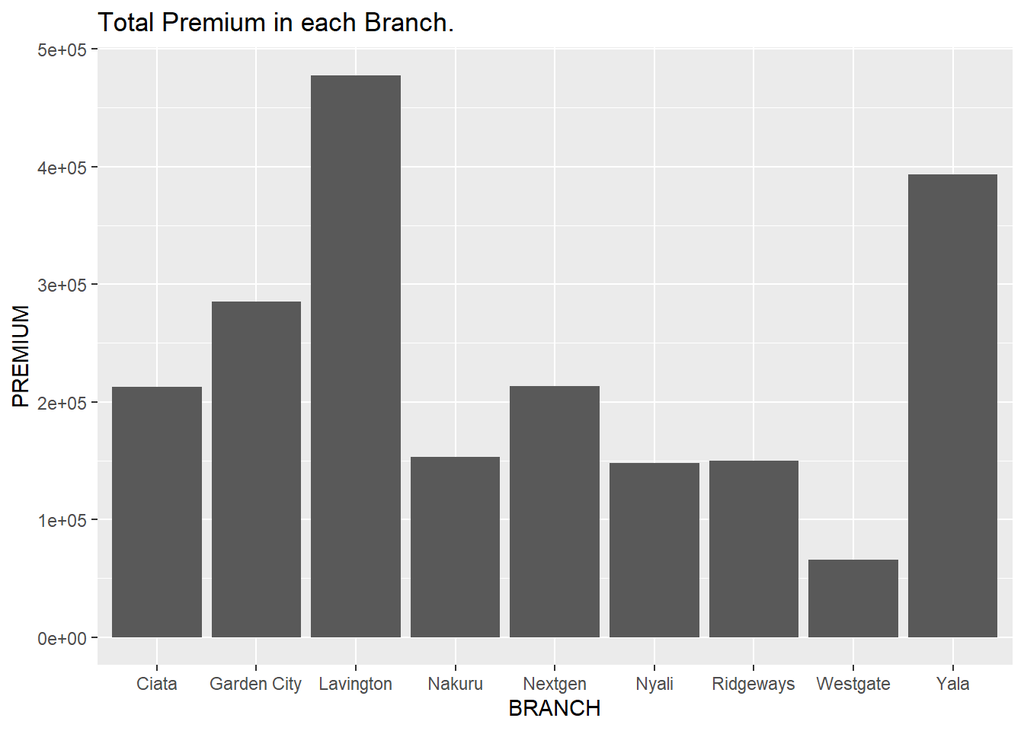

From the plot Lavington is still taking the lead from the rest. The general idea here is the more the count the more the premium, this might not always be true cause the premium amount differs but from the two graphs about, it supports the suggested idea.

Lets take a look at employees in all branches and how the performed. Who has the higest number of engagements.

## Employee with the highest number of engagement.

```
## # A tibble: 10 × 2
## # Groups:   CREATED.BY [10]
##    CREATED.BY     n
##    <chr>      <int>
##  1 Faith        441
##  2 Edah         236
##  3 Annabel      179
##  4 Diana        175
##  5 Johnstone    148
##  6 Laura        145
##  7 Ruth         139
##  8 Mercy        135
##  9 Justina      130
## 10 Monica       130
```

# Lavington.

Given that Lavington branch was the lead,lets dive into it and get a better view of the employees. ## Employee Engagement

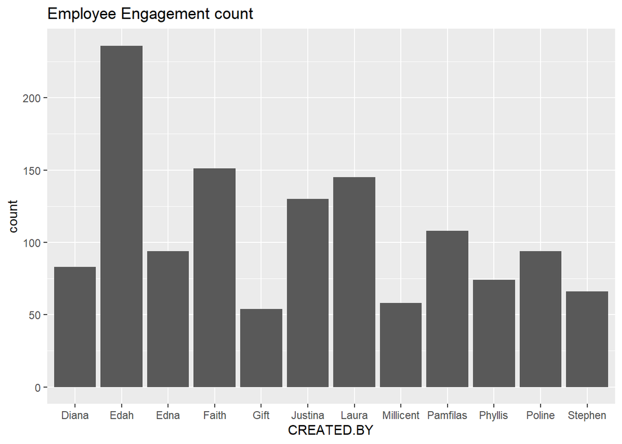

Edah had the highest engagement count, way higher than the rest. According to the graph the employee performance can be seen clearly from who is best performing to who is least performing.

Below is a plot that shows the premium per employee. Shows which employee is generation more premiums towards the business and can be used to guage performance. ## Premium per employee.

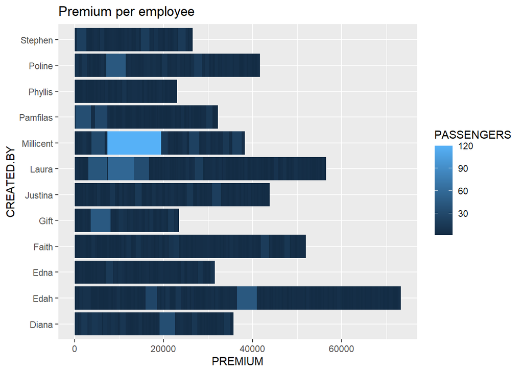

## Destination Counties.

Taking a look as the various destination counties visited by the passengers. This can shade some light on which counties passengers prefer the most and how do the premium compare in all of them. This in turn can aid in guiding marketing strategies.